# Wheat Dataset Exploration and Analysis

Sebastian Dohne

June 2025

## Project overview

The this is the dataset I have for my final project detailed below titled: Predicting crop yields in selected region using multivariate statistical and ML approaches

This project aims to predict crop yields in a selected region by leveraging data-driven methods, including multivariate statistical analyses and machine learning (ML) approaches. the dataset includes a combination of environmental, climatic, and socio-economic data to build robust models that predict crop yields with high accuracy. The project will involve tasks such as data preprocessing, covariate selection, spatial and temporal autocorrelation detection, and model tuning.

Currently, the methods that I am looking at in regards to ML are: Random Forest, XGboost and elastic nets and possibly SVRs where deemed appropriate, as these methods can handle categorical and numerical datatypes. From there, my next step was to use more traditional approaches, such as general additive models and non-linear regression to do analyses with the variables deemed most important via ML.

## Overview

This analysis explores a wheat dataset containing yield information across different countries, locations, and time periods. The primary objectives are:

- Perform comprehensive data cleaning and quality assessment
- Create interactive visualizations to understand geographic and temporal patterns
- Assess data completeness and identify missing value patterns
- Evaluate the datasets suitability for machine learning applications using quantitative metrics

## Load Required Libraries

```r
  library(data.table)    # For fast file reading
  library(tidyverse)     # Data manipulation
  library(knitr)         # Tables
  library(ggplot2)       # Static plots only
  library(scales)        # For formatting
  library(leaflet)
  library(gt)
  library(kableExtra)
  library(plotly)  # Add this to your libraries section
  library(terra)

# Parallel processing
library(furrr)        # Parallel mapping functions
```

## Data Loading and Initial Exploration

```r
# Load wheat data with irrigation and rainfall calendar information
# Note: fileEncoding handles special characters in country/location names
# Update this path to match where your CSV file is located:
data <- read.csv("../../../../data/Data/chatgptdata/23-05-mergedwheatdatafixed.csv", fileEncoding = "utf-8")

#Load raster file
aez_raster <- terra::rast("../../../../data/MSc - Sebastian/gbcl-wheat-msc/data-raw/otherdata/aez_v9v2red_5m_CRUTS32_Hist_8110_100_avg.tif")
```

### Data overview

```r
cat("Dataset dimensions:", dim(data), "\n")
```

```
## Dataset dimensions: 78179 108
```

```r
cat("Number of countries:", length(unique(data$Country)), "\n")
```

```
## Number of countries: 39
```

```r
cat("Time period covered:", range(data$Observation.period, na.rm = TRUE), "\n")
```

```
## Time period covered: 1980 2022
```

```r
# Display all column names for reference
names(data)
```

```
##   [1] "id"
##   [2] "Data.ID"
##   [3] "Location"
##   [4] "State.Region.County.Province"
##   [5] "Country"
##   [6] "Continent"
##   [7] "Latitude..N.S."
##   [8] "Longitude..E.W."
##   [9] "Conversion.for.latitude"
##  [10] "Conversion.for.longitude"
##  [11] "Location.source"
##  [12] "Observation.period"
##  [13] "Wheat.Type"
##  [14] "Crop.variety"
##  [15] "Tillage.type"
```

[output cut: 93 more lines]

## Data Cleaning and Preprocessing

### Column Selection and Type Conversion

```r
# Select key variables and rename for easier handling
yield <- data %>%
  select(Country,
         Observation.period,
         Location,
         Continent,
         State.Region.County.Province,
         longitude = Conversion.for.longitude,    # Rename for clarity
         latitude = Conversion.for.latitude,      # Rename for clarity
         yield_value = Grain.yield..tons.ha.1.) %>%  # Main outcome variable
  mutate(
    # Convert character columns to appropriate numeric types
    longitude = as.numeric(longitude),
    latitude = as.numeric(latitude),
    yield_value = as.numeric(yield_value),
    Observation.period = as.numeric(Observation.period)
  ) %>%
  filter(
    # Remove problematic observations
    !is.na(yield_value),                    # Remove missing yield values
    !is.na(longitude),                      # Remove missing coordinates
    !is.na(latitude),
    yield_value <= 30,                      # Remove unrealistic yield outliers (>30 tons/ha)
    nchar(as.character(Observation.period)) == 4  # Keep only 4-digit years
  )

cat("Cleaned dataset dimensions:", dim(yield), "\n")
```

```
## Cleaned dataset dimensions: 78011 8
```

```r
cat("Yield range:", range(yield$yield_value), "tons/ha\n")
```

```
## Yield range: 0.01673634 28.5 tons/ha
```

## AEZ Range

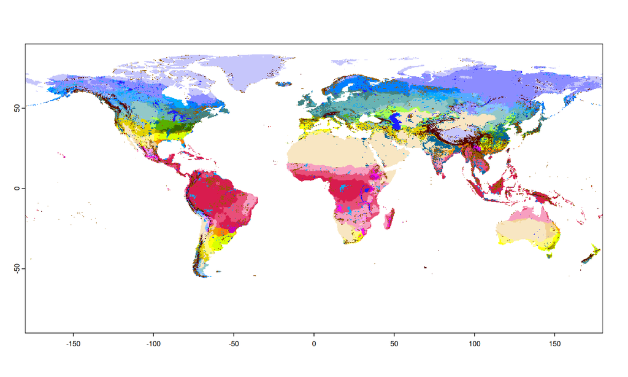

```r
plot(aez_raster)
```

## Yield Values

```r
# Create color palette for yield values
pal <- colorNumeric(palette = "YlOrRd", domain = yield$yield_value)

# Create interactive map showing global wheat yield distribution
leaflet(yield) %>%
  addTiles() %>%  # Add base map tiles
  addCircleMarkers(
    lng = ~longitude,
    lat = ~latitude,
    color = ~pal(yield_value),  # Color by yield value
    popup = ~paste("Country:", Country, "<br>",
                   "Location:", Location, "<br>",
                   "Yield:", round(yield_value, 2), "tons/ha"),
    radius = 3,
    fillOpacity = 0.7
  ) %>%
  addLegend("bottomright",
            pal = pal,
            values = ~yield_value,
            title = "Yield (tons/ha)")
```

[interactive chart not shown]

**Map Features:** - **Color coding:** Yellow to red gradient representing yield intensity - **Interactive popups:** Click markers for detailed information - **Legend:** Helps interpret yield values across locations

### Number of locations/countries per AEZ

```r
# AEZ summary: number of countries, locations, and observations per AEZ
aez_summary <- data %>%
  filter(!is.na(AEZ)) %>%
  group_by(AEZ) %>%
  summarise(
    n_observations = n(),
    n_countries = n_distinct(Country),
    n_locations = n_distinct(Location),
    .groups = 'drop'
  ) %>%
  arrange(desc(n_observations))

# Display as table
aez_summary %>%
  kable(caption = "Summary of Observations by Agroecological Zone (AEZ)") %>%
  kable_styling(full_width = FALSE, bootstrap_options = c("striped", "hover", "condensed"))
```

Summary of Observations by Agroecological Zone (AEZ)

| AEZ | n_observations | n_countries | n_locations |
| --- | --- | --- | --- |
| 27 | 37438 | 18 | 102 |
| 7 | 13520 | 2 | 2 |
| 20 | 7962 | 10 | 26 |
| 1 | 7506 | 3 | 3 |
| 10 | 3299 | 4 | 6 |
| 17 | 2359 | 4 | 10 |
| 5 | 2108 | 1 | 9 |
| 6 | 1048 | 2 | 5 |
| 13 | 663 | 4 | 10 |
| 16 | 567 | 6 | 8 |
| 26 | 364 | 3 | 4 |
| 29 | 261 | 4 | 4 |
| 25 | 201 | 2 | 2 |
| 21 | 140 | 8 | 18 |
| 32 | 124 | 4 | 6 |
| 19 | 122 | 3 | 6 |
| 11 | 114 | 4 | 8 |
| 28 | 107 | 3 | 4 |
| 8 | 40 | 2 | 2 |
| 12 | 40 | 1 | 3 |
| 18 | 29 | 2 | 4 |
| 2 | 14 | 1 | 2 |
| 3 | 8 | 1 | 1 |
| 33 | 7 | 1 | 2 |
| 9 | 6 | 1 | 1 |
| 14 | 6 | 1 | 1 |

## Temporal Analysis

### Distribution of Observations Over Time

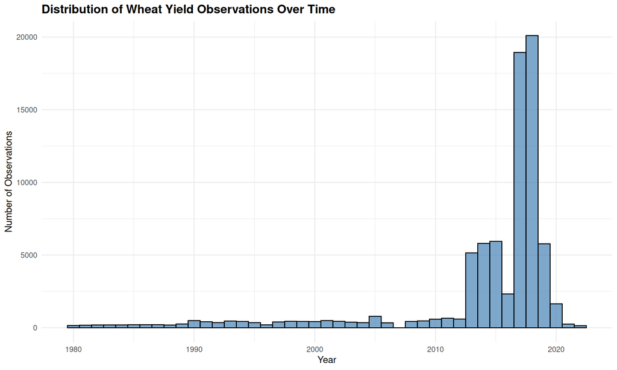

```r
# Histogram showing data collection patterns over years
ggplot(yield, aes(x = Observation.period)) +
  geom_histogram(binwidth = 1, fill = "steelblue", color = "black", alpha = 0.7) +
  theme_minimal() +
  labs(title = "Distribution of Wheat Yield Observations Over Time",
       x = "Year",
       y = "Number of Observations") +
  theme(plot.title = element_text(size = 14, face = "bold"))
```

```r
# Summary of observations and yield by year
yearly_summary <- yield %>%
  group_by(Observation.period) %>%
  summarise(
    n_observations = n(),
    mean_yield = round(mean(yield_value), 2),
    n_countries = n_distinct(Country),
    .groups = 'drop'
  ) %>%
  arrange(desc(Observation.period))

# Display recent years
head(yearly_summary, 50) %>%
  kable(caption = "Across the years: Observations and Yield Statistics")
```

Across the years: Observations and Yield Statistics

| Observation.period | n_observations | mean_yield | n_countries |
| --- | --- | --- | --- |
| 2022 | 141 | 6.52 | 2 |
| 2021 | 252 | 5.36 | 3 |
| 2020 | 1646 | 4.96 | 6 |
| 2019 | 5776 | 4.56 | 21 |
| 2018 | 20103 | 5.81 | 21 |
| 2017 | 18942 | 5.38 | 18 |
| 2016 | 2327 | 4.32 | 12 |
| 2015 | 5943 | 4.74 | 15 |
| 2014 | 5804 | 5.21 | 14 |
| 2013 | 5152 | 5.39 | 10 |
| 2012 | 598 | 5.86 | 11 |
| 2011 | 655 | 5.63 | 13 |
| 2010 | 589 | 6.28 | 6 |
| 2009 | 471 | 5.93 | 7 |
| 2008 | 433 | 6.54 | 7 |
| 2006 | 339 | 5.39 | 5 |
| 2005 | 788 | 5.22 | 6 |
| 2004 | 350 | 5.13 | 5 |
| 2003 | 384 | 4.89 | 5 |
| 2002 | 441 | 5.72 | 5 |
| 2001 | 495 | 5.86 | 4 |
| 2000 | 425 | 5.45 | 5 |
| 1999 | 433 | 6.56 | 5 |
| 1998 | 442 | 5.36 | 4 |
| 1997 | 400 | 6.04 | 6 |
| 1996 | 200 | 5.94 | 4 |
| 1995 | 351 | 6.08 | 4 |
| 1994 | 433 | 6.59 | 4 |
| 1993 | 461 | 6.04 | 4 |
| 1992 | 353 | 6.02 | 4 |
| 1991 | 414 | 7.23 | 4 |
| 1990 | 493 | 6.92 | 4 |
| 1989 | 258 | 5.30 | 4 |
| 1988 | 186 | 5.13 | 4 |
| 1987 | 211 | 5.83 | 4 |
| 1986 | 210 | 5.49 | 4 |
| 1985 | 209 | 6.33 | 4 |
| 1984 | 193 | 5.73 | 4 |
| 1983 | 193 | 5.59 | 4 |
| 1982 | 191 | 5.09 | 4 |
| 1981 | 175 | 5.46 | 4 |
| 1980 | 151 | 5.44 | 2 |

## Geographic Distribution Analysis

### Observations by Country and Continent

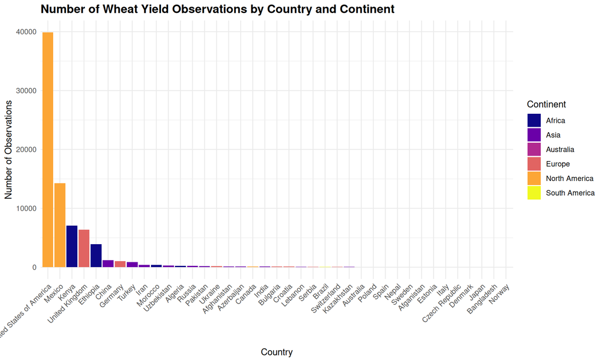

```r
# Bar plot showing observations by country, colored by continent
ggplot(yield, aes(x = reorder(Country, -table(Country)[Country]), fill = Continent)) +
  geom_bar() +
  theme_minimal() +
  labs(title = "Number of Wheat Yield Observations by Country and Continent",
       x = "Country",
       y = "Number of Observations") +
  theme(axis.text.x = element_text(angle = 45, hjust = 1),
        plot.title = element_text(size = 14, face = "bold")) +
  scale_fill_viridis_d(option = "plasma")
```

### Country-Continent Summary Table

```r
# Create organized summary table by country and continent
country_continent_table <- yield %>%
  group_by(Country, Continent) %>%
  summarise(
    count = n(),
    mean_yield = round(mean(yield_value), 2),
    .groups = 'drop'
  ) %>%
  arrange(desc(count))

# Display as formatted table
country_continent_table %>%
  head(15) %>%
  gt() %>%
  tab_header(title = "Top 15 Countries by Number of Observations") %>%
  cols_label(
    Country = "Country",
    Continent = "Continent",
    count = "Observations",
    mean_yield = "Mean Yield (tons/ha)"
  ) %>%
  fmt_number(columns = mean_yield, decimals = 2)
```

Top 15 Countries by Number of Observations

| Country | Continent | Observations | Mean Yield (tons/ha) |
| --- | --- | --- | --- |
| United States of America | North America | 39900 | 5.77 |
| Mexico | North America | 14262 | 5.17 |
| Kenya | Africa | 7053 | 4.99 |
| United Kingdom | Europe | 6397 | 5.24 |
| Ethiopia | Africa | 3909 | 3.46 |
| China | Asia | 1218 | 5.64 |
| Germany | Europe | 1056 | 7.30 |
| Turkey | Asia | 862 | 5.66 |
| Iran | Asia | 392 | 5.26 |
| Morocco | Africa | 384 | 5.35 |
| Uzbekistan | Asia | 276 | 4.00 |
| Algeria | Africa | 232 | 2.58 |
| Russia | Asia | 230 | 4.28 |
| Pakistan | Asia | 164 | 4.28 |
| Ukraine | Europe | 160 | 4.31 |

## Variable Categories Overview

### Data Type and Category Breakdown

```r
# Categorize variables by type
location_time_vars <- c("id", "Data.ID", "Location", "State.Region.County.Province",
                       "Country", "Continent", "Latitude..N.S.", "Longitude..E.W.",
                       "Conversion.for.latitude", "Conversion.for.longitude",
                       "Location.source", "Observation.period", "X", "Y", "unit_code")

crop_management_vars <- c("Wheat.Type", "Crop.variety", "Tillage.type", "Planting.date",
                         "Harvesting.date", "Flowering.stage", "Treatment", "Treatment.type",
                         "Water.regime", "Irrigation..mm.", "N.type", "N.rate..kg.N.ha.1.",
                         "N.fertilizer.management", "P.type", "P.rate..kg.P.ha.1.",
                         "Straw.return", "Plastic.film.mulching", "Planting.date.1",
                         "Harvesting.date.1", "rainfed_start_date", "rainfed_end_date",
                         "irr_start_date", "irr_end_date", "start_date", "end_date")

climate_vars <- c("Climate", "Mean.annual.temperature..Â.C.", "Mean.annual.precipitation..mm.",
                 "temp1", "temp2", "temp3", "temp4", "temp5", "temp6", "temp7", "temp8", "temp9",
                 "prc1", "prc2", "prc3", "prc4", "prc5", "prc6", "prc7", "prc8", "prc9",
                 "pr_irrigated", "AEZ", "Elevation")

soil_vars <- c("Soil.type", "Soil.depth..cm.", "Sand", "Silt", "Clay", "Soil.texture",
              "Soil.organic.carbon..g.C.kg.1.", "Soil.organic.carbon....", "TN..g.N.kg.1.",
              "C.N.ratio", "Soil.pH", "BD..g.cm.3.", "Soil_N")

yield_performance_vars <- c("Grain.yield..tons.ha.1.", "SE...22", "PFPN..kg.kg..1.",
                           "ANE..kg.kg.1.", "Replicates")

environmental_vars <- c("Cumulative.N2O.fluxes..kg.N.ha.1.", "SE...56", "SD...57",
                       "Yield.scaled.N2O.emission..g.N.Mg.1.", "SE...59", "SD...60",
                       "EFd....", "Emissions..yes.no.")

pest_weed_vars <- grep("Pest|weed|Main.weed", names(data), value = TRUE, ignore.case = TRUE)

# Create summary table
category_summary <- data.frame(
  Category = c("Location & Time", "Crop & Management", "Climate", "Soil Properties",
               "Yield & Performance", "Environmental Impact", "Pest & Weed"),
  Variables = c(length(location_time_vars), length(crop_management_vars),
                length(climate_vars), length(soil_vars), length(yield_performance_vars),
                length(environmental_vars), length(pest_weed_vars)),
  Data_Types = c("Mixed", "Mixed", "Numeric", "Mixed", "Numeric", "Numeric", "Mixed")
)

category_summary %>%
  gt() %>%
  tab_header(title = "Dataset Structure: Variables by Category") %>%
  cols_label(
    Category = "Variable Category",
    Variables = "Number of Variables",
    Data_Types = "Primary Data Types"
  )
```

Dataset Structure: Variables by Category

| Variable Category | Number of Variables | Primary Data Types |
| --- | --- | --- |
| Location & Time | 15 | Mixed |
| Crop & Management | 25 | Mixed |
| Climate | 24 | Numeric |
| Soil Properties | 13 | Mixed |
| Yield & Performance | 5 | Numeric |
| Environmental Impact | 8 | Numeric |
| Pest & Weed | 12 | Mixed |

```r
# Show data types breakdown
data_types <- data %>%
  summarise_all(class) %>%
  pivot_longer(everything(), names_to = "Variable", values_to = "Type") %>%
  count(Type, name = "Count") %>%
  arrange(desc(Count))

data_types %>%
  gt() %>%
  tab_header(title = "Data Types Distribution") %>%
  cols_label(Type = "Data Type", Count = "Number of Variables")
```

Data Types Distribution

| Data Type | Number of Variables |
| --- | --- |
| character | 47 |
| numeric | 45 |
| integer | 14 |
| logical | 2 |

## Data Coverage Summary

### Completeness by Variable Category

```r
# Function to calculate completeness for variable groups
calculate_completeness <- function(data, var_list, category_name) {
  if(length(var_list) > 0) {
    available_vars <- intersect(var_list, names(data))
    if(length(available_vars) > 0) {
      complete_any <- data %>%
        select(all_of(available_vars)) %>%
        mutate(has_any_data = rowSums(!is.na(.)) > 0) %>%
        pull(has_any_data) %>%
        sum()

      complete_all <- data %>%
        select(all_of(available_vars)) %>%
        complete.cases() %>%
        sum()

      return(data.frame(
        Category = category_name,
        Variables_Available = length(available_vars),
        Obs_With_Any_Data = complete_any,
        Obs_With_Complete_Data = complete_all,
        Pct_Any_Data = round(complete_any / nrow(data) * 100, 1),
        Pct_Complete_Data = round(complete_all / nrow(data) * 100, 1)
      ))
    }
  }
  return(NULL)
}

# Calculate completeness for each category
coverage_summary <- bind_rows(
  calculate_completeness(data, climate_vars, "Climate"),
  calculate_completeness(data, soil_vars, "Soil Properties"),
  calculate_completeness(data, crop_management_vars, "Crop & Management"),
  calculate_completeness(data, yield_performance_vars, "Yield & Performance"),
  calculate_completeness(data, environmental_vars, "Environmental Impact")
)

coverage_summary %>%
  gt() %>%
  tab_header(title = "Data Coverage by Category") %>%
  cols_label(
    Category = "Variable Category",
    Variables_Available = "Variables",
    Obs_With_Any_Data = "Obs. w/ Any Data",
    Obs_With_Complete_Data = "Obs. w/ Complete Data",
    Pct_Any_Data = "% Any Data",
    Pct_Complete_Data = "% Complete"
  )
```

Data Coverage by Category

| Variable Category | Variables | Obs. w/ Any Data | Obs. w/ Complete Data | % Any Data | % Complete |
| --- | --- | --- | --- | --- | --- |
| Climate | 24 | 78179 | 1447 | 100.0 | 1.9 |
| Soil Properties | 13 | 77721 | 0 | 99.4 | 0.0 |
| Crop & Management | 25 | 78179 | 0 | 100.0 | 0.0 |
| Yield & Performance | 5 | 78172 | 295 | 100.0 | 0.4 |
| Environmental Impact | 8 | 11002 | 0 | 14.1 | 0.0 |

## Variable Completeness Dashboard

### Comprehensive Variable Assessment

```r
# Create comprehensive variable summary
var_summary <- data %>%
  summarise_all(list(
    count = ~sum(!is.na(.)),
    pct_complete = ~round(sum(!is.na(.)) / n() * 100, 1),
    min_val = ~ifelse(is.numeric(.), round(min(., na.rm = TRUE), 2), NA),
    max_val = ~ifelse(is.numeric(.), round(max(., na.rm = TRUE), 2), NA),
    n_unique = ~n_distinct(., na.rm = TRUE)
  )) %>%
  pivot_longer(everything(), names_to = "variable_stat", values_to = "value") %>%
  separate(variable_stat, into = c("variable", "statistic"), sep = "_(?=count$|pct_complete$|min_val$|max_val$|n_unique$)") %>%
  pivot_wider(names_from = statistic, values_from = value) %>%
  arrange(desc(pct_complete))

# Display all variables by completeness
var_summary %>%
  gt() %>%
  tab_header(title = "All Variables by Data Completeness") %>%
  cols_label(
    variable = "Variable",
    count = "Count",
    pct_complete = "% Complete",
    min_val = "Min Value",
    max_val = "Max Value",
    n_unique = "Unique Values"
  ) %>%
  fmt_number(columns = c(pct_complete), decimals = 1)
```

All Variables by Data Completeness

| Variable | Count | % Complete | Min Value | Max Value | Unique Values |
| --- | --- | --- | --- | --- | --- |
| id | 78179 | 100.0 | 1.00 | 80154.00 | 77785 |
| Data.ID | 78179 | 100.0 | NA | NA | 55 |
| Location | 78179 | 100.0 | NA | NA | 243 |
| Country | 78179 | 100.0 | NA | NA | 39 |
| Continent | 78179 | 100.0 | NA | NA | 6 |
| Latitude..N.S. | 78179 | 100.0 | NA | NA | 262 |
| Longitude..E.W. | 78179 | 100.0 | NA | NA | 266 |
| Conversion.for.latitude | 78179 | 100.0 | -37.82 | 60.70 | 251 |
| Conversion.for.longitude | 78179 | 100.0 | -121.93 | 152.39 | 251 |
| Location.source | 78179 | 100.0 | NA | NA | 9 |
| Observation.period | 78179 | 100.0 | 1980.00 | 2022.00 | 42 |
| Grain.yield..tons.ha.1. | 78170 | 100.0 | 0.02 | 8830.80 | 15422 |
| X | 78179 | 100.0 | -121.93 | 152.39 | 251 |
| Y | 78179 | 100.0 | -37.82 | 60.70 | 251 |
| unit_code | 78179 | 100.0 | 4000.00 | 860000.00 | 69 |
| start_date | 78179 | 100.0 | 5.00 | 12.00 | 6 |
| end_date | 78179 | 100.0 | 2.00 | 11.00 | 9 |
| pr_irrigated | 78179 | 100.0 | 0.00 | 100.00 | 194 |
| Elevation | 78179 | 100.0 | -36.00 | 3028.00 | 201 |
| AEZ | 78053 | 99.8 | 1.00 | 33.00 | 26 |
| temp1 | 78053 | 99.8 | -1.46 | 34.40 | 307 |
| temp2 | 78053 | 99.8 | -12.13 | 29.02 | 307 |
| temp3 | 78053 | 99.8 | -13.21 | 29.34 | 311 |
| temp4 | 78053 | 99.8 | -25.59 | 29.82 | 317 |
| temp5 | 78053 | 99.8 | -21.07 | 31.09 | 317 |
| temp6 | 78053 | 99.8 | -12.64 | 33.62 | 318 |
| temp7 | 78053 | 99.8 | -9.69 | 34.06 | 317 |
| temp8 | 78053 | 99.8 | 1.88 | 36.85 | 317 |
| temp9 | 78053 | 99.8 | 10.41 | 35.61 | 318 |
| prc1 | 78053 | 99.8 | 0.00 | 9.76 | 304 |

[output cut: 78 more lines]

## Data Source and Quality Indicators

### ML Readiness Assessment

```r
# Assess dataset readiness for ML
ml_readiness <- data.frame(
  Assessment_Category = c(
    "Sample Size",
    "Geographic Coverage",
    "Temporal Coverage",
    "Target Variable (Yield)",
    "Climate Variables",
    "Soil Variables",
    "Management Variables",
    "Overall ML Readiness"
  ),

  Status = c(
    ifelse(nrow(data) >= 100, "✓ Good", "⚠ Limited"),
    ifelse(length(unique(data$Country)) >= 5, "✓ Good", "⚠ Limited"),
    ifelse(max(data$Observation.period, na.rm = TRUE) - min(data$Observation.period, na.rm = TRUE) >= 10, "✓ Good", "⚠ Limited"),
    ifelse(sum(!is.na(data$Grain.yield..tons.ha.1.)) / nrow(data) >= 0.8, "✓ Good", "⚠ Limited"),
    ifelse(sum(!is.na(data$Mean.annual.temperature..Â.C.)) / nrow(data) >= 0.5, "✓ Good", "⚠ Limited"),
    ifelse(sum(!is.na(data$Soil.pH)) / nrow(data) >= 0.3, "✓ Good", "⚠ Limited"),
    ifelse(sum(!is.na(data$N.rate..kg.N.ha.1.)) / nrow(data) >= 0.3, "✓ Good", "⚠ Limited"),
    "Ready for Analysis"
  ),

  Details = c(
    paste(nrow(data), "observations"),
    paste(length(unique(data$Country)), "countries"),
    paste(max(data$Observation.period, na.rm = TRUE) - min(data$Observation.period, na.rm = TRUE), "year span"),
    paste(round(sum(!is.na(data$Grain.yield..tons.ha.1.)) / nrow(data) * 100, 1), "% complete"),
    paste(round(sum(!is.na(data$Mean.annual.temperature..Â.C.)) / nrow(data) * 100, 1), "% complete"),
    paste(round(sum(!is.na(data$Soil.pH)) / nrow(data) * 100, 1), "% complete"),
    paste(round(sum(!is.na(data$N.rate..kg.N.ha.1.)) / nrow(data) * 100, 1), "% complete"),
    "Proceed with feature selection"
  )
)

ml_readiness %>%
  gt() %>%
  tab_header(title = "Machine Learning Readiness Assessment") %>%
  cols_label(
    Assessment_Category = "Category",
    Status = "Status",
    Details = "Details"
  )
```

Machine Learning Readiness Assessment

| Category | Status | Details |
| --- | --- | --- |
| Sample Size | ✓ Good | 78179 observations |
| Geographic Coverage | ✓ Good | 39 countries |
| Temporal Coverage | ✓ Good | 42 year span |
| Target Variable (Yield) | ✓ Good | 100 % complete |
| Climate Variables | ⚠ Limited | 19.8 % complete |
| Soil Variables | ✓ Good | 99.3 % complete |
| Management Variables | ✓ Good | 92.2 % complete |
| Overall ML Readiness | Ready for Analysis | Proceed with feature selection |